# Análise de Dados em R - Bloco 4

## Baixar um banco de dados da internet pelo R

Uma funcionalidade disponível em R é a de baixar arquivos diretamente da web, a partir do link do arquivo. Vamos baixar o banco “data_inova_2008” disponível [aqui](https://raw.githubusercontent.com/claudioalvesmonteiro/municipality-inovation/master/Analysis%20Data/data_inova_2008.csv).

1. Copie o endereço da página web
2. Armazene-o em um objeto como uma *string*
3. Armazene o nome do arquivo em outro objeto
4. Passe o endereço como primeiro argumento e o nome do arquivo como segundo na função *download.file()*

**Obs:**O arquivo será salvo no seu diretório de trabalho atual, verifique-se de que o ambiente se encontra no devido diretório.

## Manipulando a base

1 - Importe o banco de dados para o R

2 - Informe a estatística descritiva (valor mínimo, máximo, média e desvio-padrão) das seguintes variáveis do banco: *bur_escol_2008, bur_terc_2008, rec_orcamento_2008, iqb_pcr_2008, cand_age_2008 e cand_sex_2008*

## Visualização de Dados

Agora vamos trabalhar com a visualização gráfica de algumas informações relevantes.

### 1. Gráfico de barra

Primeiro vamos fazer um gráfico de barra com a média do Indicador de Qualidade da Burocracia Municipal (IQBM) por estado da federação. Temos uma base de dados dos municípios, então devemos calcular a média do IQBM de cada estado com base nos valores de seus respectivos municípios:

##### A função *aggregate* é uma ferramente muito útil na análise de dados em R. Ela aplica uma determinada função a um conjunto de valores. Em nosso exemplo queremos aplicar a função *mean()* para os valores do IQBM, por estado.

```r
# executar funcao aggregate
estadoIQB <- aggregate(
  # define a variavel de calculo
  x = data_inova_2008$iqb_pcr_2008,
  # define a variavel categorica dos estados
  by = list(data_inova_2008$Nome_UF),
  # define a funcao a ser aplicada
  FUN = mean)

# visualizar resultado
estadoIQB
```

```
##                Group.1         x
## 1                 Acre 0.9354807
## 2              Alagoas 0.9406192
## 3                Amapá 0.9194295
## 4             Amazonas 0.9369311
## 5                Bahia 0.9254668
## 6                Ceará 0.9394888
## 7       Espírito Santo 0.9249415
## 8                Goiás 0.9211735
## 9             Maranhão 0.9327956
## 10         Mato Grosso 0.9358729
## 11  Mato Grosso do Sul 0.9389809
## 12        Minas Gerais 0.9351460
## 13                Pará 0.9244309
## 14             Paraíba 0.9241058
## 15              Paraná 0.9470350
## 16          Pernambuco 0.9253121
## 17               Piauí 0.9339717
## 18      Rio de Janeiro 0.9349389
## 19 Rio Grande do Norte 0.9313279
## 20   Rio Grande do Sul 0.9434081
## 21            Rondônia 0.9338547
## 22             Roraima 0.8953674
## 23      Santa Catarina 0.9454240
## 24           São Paulo 0.9459630
## 25             Sergipe 0.9259566
## 26           Tocantins 0.9256954
```

##### Agora vamos construir nosso gráfico:

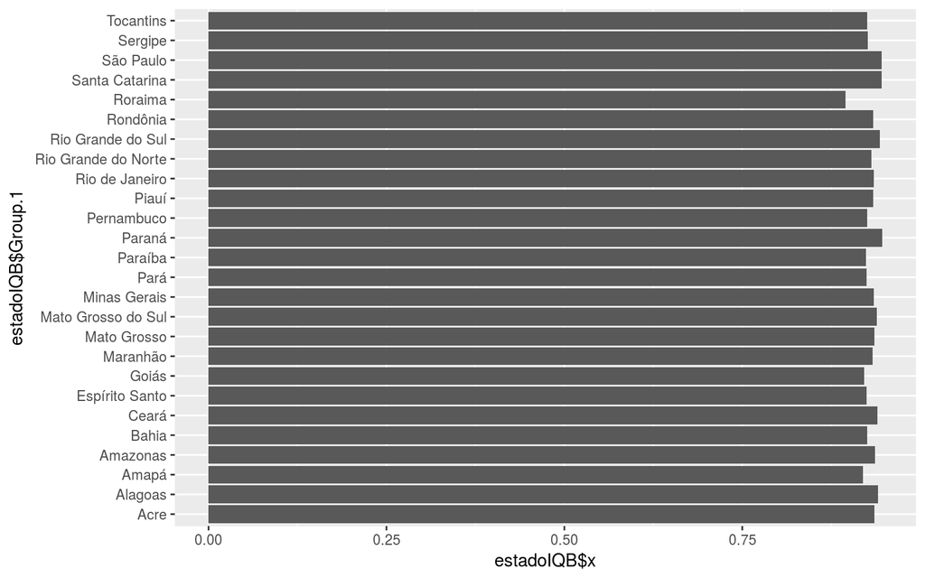

```r
# carregar pacote
library(ggplot2)

# define a base de dados, eixo x e eixo y
ggplot(data = estadoIQB, aes(x = estadoIQB$Group.1, y = estadoIQB$x))+
  # define o tipo de barra
  geom_bar(stat = "identity")+
  # girar barra para horizontal
  coord_flip()
```

Podemos ainda evoluir a visualização do gráfico. Vamos dar uma olhada nas possibilidades que o R dispõe:

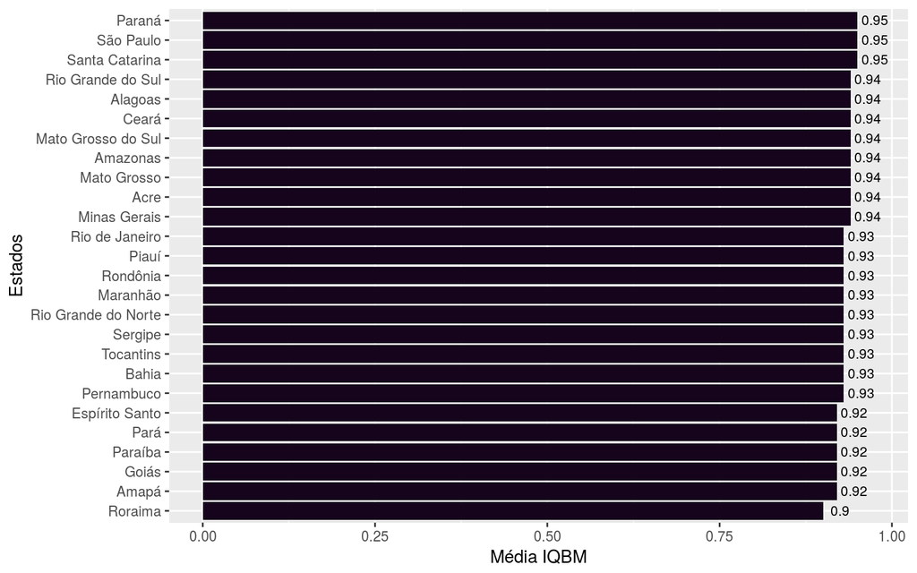

```r
 # ordena os dados com base na variavel 'x'
estadoIQB <- estadoIQB[order(estadoIQB$x),]
# tranforma os nomes em fatores com os niveis da ordem
estadoIQB$Group.1 <- factor(estadoIQB$Group.1, levels = estadoIQB$Group.1)

# arredondar valores
estadoIQB$x <- round(estadoIQB$x, 2)

# novo grafico
plotEstadoIQB <-
  # define a base de dados, eixo x e eixo y
  ggplot(data = estadoIQB, aes(x = estadoIQB$Group.1, y = estadoIQB$x))+
  # define o tipo de barra e a cor
  geom_bar(stat = "identity", fill = "#15041c")+
  # adicionar os valores nas barras, define tamanho e posicao
  geom_text(aes(label = estadoIQB$x), size = 3, nudge_y = 0.025)+
  # renomear os eixos
  labs(x = "Estados", y = "Média IQBM")+
  # girar barra para horizontal
  coord_flip()

plotEstadoIQB
```

Por fim vamos salvar o grafico no diretorio de trabalho:

```r
ggsave("plotEstadoIQB.png", # nome do arquivo a ser salvo
       plotEstadoIQB,       # objeto grafico a ser salvo
       width = 7,           # tamanho horizontal
       height = 7,          # tamanho vertical
       units = "in")        # unidade de medida (in = inches = polegadas)
```

Claudio A. Monteiro

Maio, 2018